# US Accidents Analysis from 2016 to 2021

- In this project, I am trying to look at accidents in the US between 2016 and 2021.
- I am trying to do EDA on the data to see what is the accident distribution in the US. What are the highest and lowest stats? What Factors could impact the number of accidents either in a positive or negative way?
- I am using the [US accidents dataset](https://www.kaggle.com/datasets/sobhanmoosavi/us-accidents) from kaggle

# US Accidents Exploratory Data Analysis

## Download data

```python
pip install opendatasets --upgrade --quiet
```

```python
import opendatasets as od
dataset_url = 'https://www.kaggle.com/datasets/sobhanmoosavi/us-accidents'
od.download(dataset_url)
```

```
Please provide your Kaggle credentials to download this dataset. Learn more: http://bit.ly/kaggle-creds
Your Kaggle username: ibrahimothman
Your Kaggle Key: ··········
Downloading us-accidents.zip to ./us-accidents
```

```python
data_filename = './us-accidents/US_Accidents_Dec21_updated.csv'
```

## Data preparation & cleaning

1. Load dataset using Pandas
2. Look at some inforamtion about the dataset
3. Fix missing & incorrect values

```python
import pandas as pd
```

```python
df = pd.read_csv(data_filename)
```

```python
df.head()
```

|  | ID | Severity | Start_Time | End_Time | Start_Lat | Start_Lng | End_Lat | End_Lng | Distance(mi) | Description | ... | Roundabout | Station | Stop | Traffic_Calming | Traffic_Signal | Turning_Loop | Sunrise_Sunset | Civil_Twilight | Nautical_Twilight | Astronomical_Twilight |
| --- | --- | --- | --- | --- | --- | --- | --- | --- | --- | --- | --- | --- | --- | --- | --- | --- | --- | --- | --- | --- | --- |
| 0 | A-1 | 3 | 2016-02-08 00:37:08 | 2016-02-08 06:37:08 | 40.108910 | -83.092860 | 40.112060 | -83.031870 | 3.230 | Between Sawmill Rd/Exit 20 and OH-315/Olentang... | ... | False | False | False | False | False | False | Night | Night | Night | Night |
| 1 | A-2 | 2 | 2016-02-08 05:56:20 | 2016-02-08 11:56:20 | 39.865420 | -84.062800 | 39.865010 | -84.048730 | 0.747 | At OH-4/OH-235/Exit 41 - Accident. | ... | False | False | False | False | False | False | Night | Night | Night | Night |
| 2 | A-3 | 2 | 2016-02-08 06:15:39 | 2016-02-08 12:15:39 | 39.102660 | -84.524680 | 39.102090 | -84.523960 | 0.055 | At I-71/US-50/Exit 1 - Accident. | ... | False | False | False | False | False | False | Night | Night | Night | Day |
| 3 | A-4 | 2 | 2016-02-08 06:51:45 | 2016-02-08 12:51:45 | 41.062130 | -81.537840 | 41.062170 | -81.535470 | 0.123 | At Dart Ave/Exit 21 - Accident. | ... | False | False | False | False | False | False | Night | Night | Day | Day |
| 4 | A-5 | 3 | 2016-02-08 07:53:43 | 2016-02-08 13:53:43 | 39.172393 | -84.492792 | 39.170476 | -84.501798 | 0.500 | At Mitchell Ave/Exit 6 - Accident. | ... | False | False | False | False | False | False | Day | Day | Day | Day |

5 rows × 47 columns

```python
df.info()
```

```
<class 'pandas.core.frame.DataFrame'>
RangeIndex: 2845342 entries, 0 to 2845341
Data columns (total 47 columns):
 #   Column                 Dtype
---  ------                 -----
 0   ID                     object
 1   Severity               int64
 2   Start_Time             object
 3   End_Time               object
 4   Start_Lat              float64
 5   Start_Lng              float64
 6   End_Lat                float64
 7   End_Lng                float64
 8   Distance(mi)           float64
 9   Description            object
```

[output cut: 39 more lines]

```python
df.describe()
```

|  | Severity | Start_Lat | Start_Lng | End_Lat | End_Lng | Distance(mi) | Number | Temperature(F) | Wind_Chill(F) | Humidity(%) | Pressure(in) | Visibility(mi) | Wind_Speed(mph) | Precipitation(in) |
| --- | --- | --- | --- | --- | --- | --- | --- | --- | --- | --- | --- | --- | --- | --- |
| count | 2.845342e+06 | 2.845342e+06 | 2.845342e+06 | 2.845342e+06 | 2.845342e+06 | 2.845342e+06 | 1.101431e+06 | 2.776068e+06 | 2.375699e+06 | 2.772250e+06 | 2.786142e+06 | 2.774796e+06 | 2.687398e+06 | 2.295884e+06 |
| mean | 2.137572e+00 | 3.624520e+01 | -9.711463e+01 | 3.624532e+01 | -9.711439e+01 | 7.026779e-01 | 8.089408e+03 | 6.179356e+01 | 5.965823e+01 | 6.436545e+01 | 2.947234e+01 | 9.099391e+00 | 7.395044e+00 | 7.016940e-03 |
| std | 4.787216e-01 | 5.363797e+00 | 1.831782e+01 | 5.363873e+00 | 1.831763e+01 | 1.560361e+00 | 1.836009e+04 | 1.862263e+01 | 2.116097e+01 | 2.287457e+01 | 1.045286e+00 | 2.717546e+00 | 5.527454e+00 | 9.348831e-02 |
| min | 1.000000e+00 | 2.456603e+01 | -1.245481e+02 | 2.456601e+01 | -1.245457e+02 | 0.000000e+00 | 0.000000e+00 | -8.900000e+01 | -8.900000e+01 | 1.000000e+00 | 0.000000e+00 | 0.000000e+00 | 0.000000e+00 | 0.000000e+00 |
| 25% | 2.000000e+00 | 3.344517e+01 | -1.180331e+02 | 3.344628e+01 | -1.180333e+02 | 5.200000e-02 | 1.270000e+03 | 5.000000e+01 | 4.600000e+01 | 4.800000e+01 | 2.931000e+01 | 1.000000e+01 | 3.500000e+00 | 0.000000e+00 |
| 50% | 2.000000e+00 | 3.609861e+01 | -9.241808e+01 | 3.609799e+01 | -9.241772e+01 | 2.440000e-01 | 4.007000e+03 | 6.400000e+01 | 6.300000e+01 | 6.700000e+01 | 2.982000e+01 | 1.000000e+01 | 7.000000e+00 | 0.000000e+00 |
| 75% | 2.000000e+00 | 4.016024e+01 | -8.037243e+01 | 4.016105e+01 | -8.037338e+01 | 7.640000e-01 | 9.567000e+03 | 7.600000e+01 | 7.600000e+01 | 8.300000e+01 | 3.001000e+01 | 1.000000e+01 | 1.000000e+01 | 0.000000e+00 |
| max | 4.000000e+00 | 4.900058e+01 | -6.711317e+01 | 4.907500e+01 | -6.710924e+01 | 1.551860e+02 | 9.999997e+06 | 1.960000e+02 | 1.960000e+02 | 1.000000e+02 | 5.890000e+01 | 1.400000e+02 | 1.087000e+03 | 2.400000e+01 |

```python
# How many numeric columns we have
numerics = ['int16', 'int32', 'int64', 'float16', 'float32', 'float64']
numeric_df = df.select_dtypes(include=numerics)
len(numeric_df.columns)
```

```
14
```

Percantage of missing values per column

```python
# Missing & incorrect values
missing_perc = df.isna().sum().sort_values(ascending=False) / len(df)
missing_perc = missing_perc[missing_perc > 0]
missing_perc
```

```
Number                   6.129003e-01
Precipitation(in)        1.931079e-01
Wind_Chill(F)            1.650568e-01
Wind_Speed(mph)          5.550967e-02
Wind_Direction           2.592834e-02
Humidity(%)              2.568830e-02
Weather_Condition        2.482514e-02
Visibility(mi)           2.479350e-02
Temperature(F)           2.434646e-02
Pressure(in)             2.080593e-02
Weather_Timestamp        1.783125e-02
Airport_Code             3.356011e-03
Timezone                 1.285961e-03
Nautical_Twilight        1.007612e-03
Civil_Twilight           1.007612e-03
Sunrise_Sunset           1.007612e-03
Astronomical_Twilight    1.007612e-03
Zipcode                  4.635647e-04
City                     4.814887e-05
Street                   7.029032e-07
dtype: float64
```

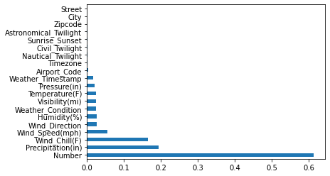

```python
missing_perc.plot(kind='barh')
```

## Exploratory Data Analysis & visualization

Columns I'll analyze:

- City
- Start time
- Start Lat, Lng
- Temperature
- Weather condition

### City

```python
cities = df.City.unique()
len(cities)
```

```
11682
```

```python
cities_by_accidents = df.City.value_counts().sort_values(ascending=False)
cities_by_accidents[:20]
```

```
Miami           106966
Los Angeles      68956
Orlando          54691
Dallas           41979
Houston          39448
Charlotte        33152
Sacramento       32559
San Diego        26627
Raleigh          22840
Minneapolis      22768
Portland         20944
Nashville        20267
Austin           18301
Baton Rouge      18182
Phoenix          17143
Saint Paul       16869
New Orleans      16251
Atlanta          15622
Jacksonville     14967
Richmond         14349
Name: City, dtype: int64
```

```python
 'New York' in df.City
```

```
False
```

```python
'NY' in df.State
# there are 50 states in the US but dataset just have 49
```

```
False
```

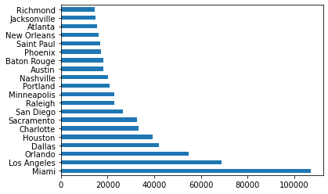

```python
cities_by_accidents[:20].plot(kind='barh')
```

```python
# most cities have high or small number of accidents?
import seaborn as sns
sns.set_style('darkgrid')
```

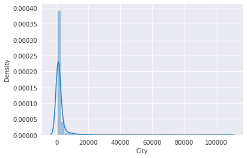

```python
sns.distplot(cities_by_accidents[:1000])
```

Seems like most cities have very few numbers of accidents. Let's create two buckets for high & small

```python
high_accident_cities = cities_by_accidents[cities_by_accidents >= 1000]
low_accidents_cities = cities_by_accidents[cities_by_accidents < 1000]
```

```python
len(high_accident_cities) / len(cities_by_accidents)
```

```
0.04246211796935194
```

```python
len(low_accidents_cities) / len(cities_by_accidents)
```

```
0.957537882030648
```

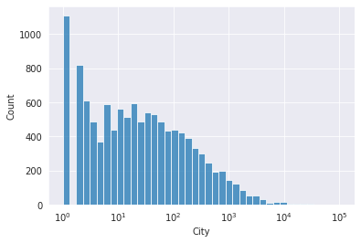

```python
# let's try log scale
sns.histplot(cities_by_accidents, log_scale=True)
```

```python
len(cities_by_accidents[cities_by_accidents == 1]) / len(cities_by_accidents)
```

```
0.0950261107781868
```

- Around 10% of the cities have 1 accidents? could be missing values
- Most values are between 10 - 1000

### Start time

```python
df.Start_Time
```

```
0          2016-02-08 00:37:08
1          2016-02-08 05:56:20
2          2016-02-08 06:15:39
3          2016-02-08 06:51:45
4          2016-02-08 07:53:43
                  ...
2845337    2019-08-23 18:03:25
2845338    2019-08-23 19:11:30
2845339    2019-08-23 19:00:21
2845340    2019-08-23 19:00:21
2845341    2019-08-23 18:52:06
Name: Start_Time, Length: 2845342, dtype: object
```

```python
# convert it to datetime
df['New_Start_Time'] = pd.to_datetime(df.Start_Time)
```

```python
df.New_Start_Time[0]
```

```
Timestamp('2016-02-08 00:37:08')
```

```python
# let's get to know at what time accidents happen most often?
df['Start_Time_Hour'] = df['New_Start_Time'].dt.hour
```

```python
df[['New_Start_Time', 'Start_Time_Hour']].head()
```

|  | New_Start_Time | Start_Time_Hour |
| --- | --- | --- |
| 0 | 2016-02-08 00:37:08 | 0 |
| 1 | 2016-02-08 05:56:20 | 5 |
| 2 | 2016-02-08 06:15:39 | 6 |
| 3 | 2016-02-08 06:51:45 | 6 |
| 4 | 2016-02-08 07:53:43 | 7 |

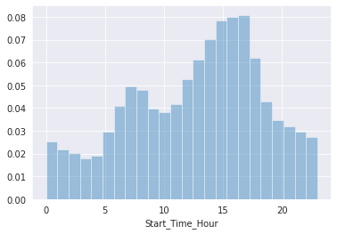

```python
sns.distplot(df.Start_Time_Hour, bins=24, kde=False, norm_hist=True)
```

- We can see high percentage of accidents happen between 7 - 10 AM (people might be in a hurry to get to work at the morning & high traffic) and between 3-6 PM (All are back home && traffic is high)

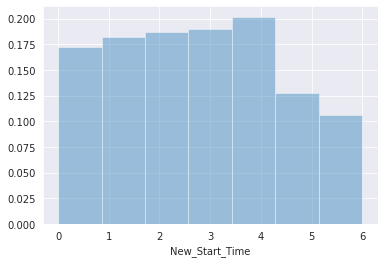

```python
sns.distplot(df.New_Start_Time.dt.dayofweek, bins=7, kde=False, norm_hist=True)
```

- On weekends number of accidents go down

Is the dist of accidents by hours the same on weekends as weekdays

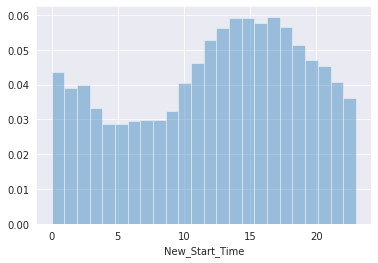

```python
sundays = df.New_Start_Time[df.New_Start_Time.dt.dayofweek == 6]
sns.distplot(sundays.dt.hour, bins=24, kde=False, norm_hist=True)
```

On sundays, a lot of traffic during the afternoon

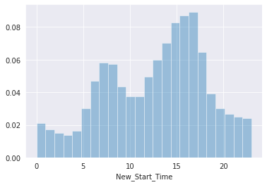

```python
Mondays = df.New_Start_Time[df.New_Start_Time.dt.dayofweek == 1]
sns.distplot(Mondays.dt.hour, bins=24, kde=False, norm_hist=True)
```

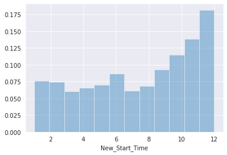

```python
sns.distplot(df.New_Start_Time.dt.month, bins=12, kde=False, norm_hist=True)
```

Getting low in the summer, keep going up towards december, Weather conditions could be the reason?

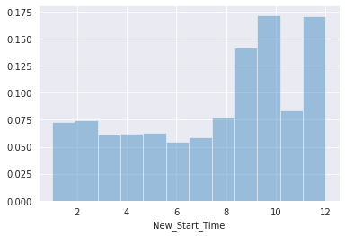

```python
df_2019 =df[ df.New_Start_Time.dt.year == 2019]
sns.distplot(df_2019.New_Start_Time.dt.month, bins=12, kde=False, norm_hist=True)
```

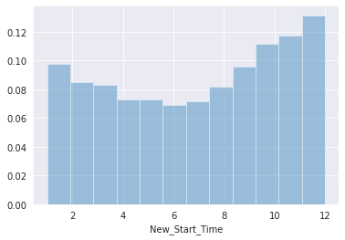

```python
df_2018 =df[ df.New_Start_Time.dt.year == 2018]
sns.distplot(df_2018.New_Start_Time.dt.month, bins=12, kde=False, norm_hist=True)
```

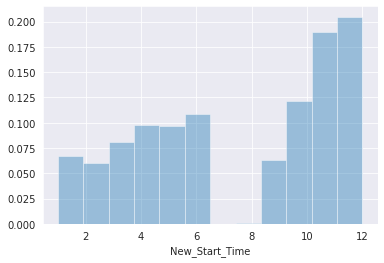

```python
df_2020 =df[ df.New_Start_Time.dt.year == 2020]
sns.distplot(df_2020.New_Start_Time.dt.month, bins=12, kde=False, norm_hist=True)
```

No accidents during the summer 2020, could be due to COVID breakout?

### Start lat,lng

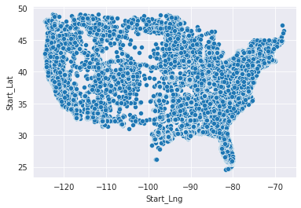

```python
sample_df = df.sample(int(0.1 * len(df))) # 10% sample
sns.scatterplot(x=sample_df.Start_Lng, y=sample_df.Start_Lat, sizes=0.001)
```

Seems like the closer we get to the coast, the more accidents are there. Less at the center

```python
# lets try to generate a heatmap using folium
import folium
from folium.plugins import HeatMap
```

```python
map = folium.Map(zoom_start = 5)
sample_df = df[['Start_Lat', 'Start_Lng']].sample(int(0.001 * len(df))) # 10% sample

# List comprehension to make out list of lists
heat_data = [[ row['Start_Lat'],row['Start_Lng']] for index, row in sample_df.iterrows()]

# Plot it on the map
HeatMap(heat_data).add_to(map)
map
```

Make this Notebook Trusted to load map: File -> Trust Notebook

[interactive chart not shown]

Try to zoom in to see it properly

# Ask & answer questions about data

- Are there more accidents in warmer or colder areas?
- Which states have the highest numbers of accidents per capita?
- Is New York in the dataset since it's the highest population state? If yes why it's not in the top 10 cities by accidents?
- Among the top 100 cities in numbers of accidents, what are their states?
- We have a lot of cities with just 1 accident per year? Any issue could be there?
- What time of the day accidents happen most?
- What day of the week they most happen?
- Month has the most accidents
- What is ther trend of accidents over years (up/down)?
- What the relation between accidents time and traffic status?

## Summary & conclusions

Insights: